# Homework 3

Ian Frankenburg

6/12/2020

# Bayesian Model Selection.

I’m just going to write out the math for this part. I want to sample from $p(\gamma|Y)$. I’ll do this by sampling from $p(\gamma, \beta_\gamma,\sigma^2|y)$. This will involve sampling from spaces of varying dimension since $\beta_\gamma$ is changing. Under model $\gamma$, I know $p(\beta_\gamma,\sigma^2|y,\gamma)$ since I did part (b) first.
$$\begin{aligned}
p(\sigma^2,\beta|y, \gamma)&\propto p(y|\gamma,\beta_\gamma,\sigma^2)p(\beta_\gamma|,\sigma^2,\gamma)p(\sigma^2|\gamma)\\
&N(m,M)\times IG(n/2-1, RSS/2),
\end{aligned}$$
with the same $m,M,$ and $RSS$ I use in part (b). Now I need to update $p(\beta_\gamma,\gamma,\sigma^2|y)$.
$$\begin{aligned}
p(\beta_\gamma,\gamma,\sigma^2|y)&\propto p(y|\beta_\gamma,\sigma^2,\gamma)p(\beta_\gamma,\sigma^2,\gamma)\\
&=p(y|\beta_\gamma,\sigma^2,\gamma)p(\beta_\gamma|\sigma^2,\gamma)p(\sigma^2|\gamma)p(\gamma)\\
&=N(m,M)\times IG(n/2-1,RSS/2)\times 2^{-q_\gamma}
\end{aligned}$$
In coding this, I’d use a Metropolis-Hastings sampler.

I know $p(\gamma|y)\propto p(y|\gamma)p(\gamma)$, so this will come down to computing $p(y|\gamma)$. Since
$$p(y|\gamma)=\int\int p(y|\beta,\sigma^2,\gamma)p(\beta|\sigma^2,\gamma)p(\sigma^2)d\beta d\sigma^2,$$
I’ll work with the integrand. I’m given that we’re using a $g$-prior, so
$$\begin{aligned}
&p(y|\beta,\sigma^2,\gamma)p(\beta|\sigma^2,\gamma)\\
=&N(y;X_\gamma\beta,\sigma^2 I)N(\beta;\frac{\sigma^2}{g}(X_\gamma^\top X_\gamma)^{-1})\\
=&(2\pi\sigma^2)^{-n/2}\exp\big(-\frac{1}{2\sigma^2}(y-X_\gamma\beta)^\top(y-X_\gamma\beta)\big)\exp\big(-\frac{g}{2\sigma^2}\beta^\top X_\gamma^\top X_\gamma\beta\big)
\end{aligned}$$
Combinging the terms in the exponent through completing the square gives
$$\begin{aligned}
&-\frac{1}{2\sigma^2}(y-X_\gamma\beta)^\top(y-X_\gamma\beta)-\frac{g}{2\sigma^2}\beta^\top X_\gamma^\top X_\gamma\beta\\
=&-\frac{1}{2}\big[y^\top y\big/\sigma^2-2\beta^\top Xy/\sigma^2+\beta^\top X_\gamma^\top X_\gamma\beta/\sigma^2 + g\beta^\top X_\gamma^\top X_\gamma\beta/\sigma^2]\\
=&-\frac{1}{2}\big[y^\top y\big/\sigma^2+(\beta-m)M^{-1}(\beta-m)+m^\top M^{-1}m]
\end{aligned}$$
where $M=\sigma^2(X_\gamma^\top X_\gamma)^{-1}/(1+g)$ and $m=MX^\top y/\sigma^2$.

That means $p(y|\beta,\sigma^2,\gamma)p(\beta|\sigma^2,\gamma)$ can be written as
$$\begin{aligned}
(2\pi\sigma^2)^{-n/2}\exp\big(-\frac{1}{2}[y^\top y\big/\sigma^2+(\beta-m)M^{-1}(\beta-m)+mM^{-1}m]\big).
\end{aligned}$$
Therefore, when I integrate $p(y|\beta,\sigma^2,\gamma)p(\beta|\sigma^2,\gamma)$, the Gaussian kernel will go away and I’ll be left with
$$\begin{aligned}
&\int p(y|\beta,\sigma^2,\gamma)p(\beta|\sigma^2,\gamma)d\beta\\
=&(2\pi\sigma^2)^{-n/2}\exp(\frac{1}{2\sigma^2}y^\top y)\exp(\frac{1}{2}m^\top M^{-1}m)|2\pi M|^{1/2}\\
=&(2\pi)^{(-n+q_\gamma)/2}(\sigma^2)^{(-n+q_\gamma)/2}|(X_\gamma^\top X_\gamma)|^{-1/2}(\frac{1}{g+1})^{q_{\gamma}/2}\exp(-\frac{1}{2\sigma^2}y^\top y)\exp(\frac{1}{2}m^\top M^{-1}m).
\end{aligned}$$
Since
$$\begin{aligned}
\exp(-\frac{1}{2\sigma^2}y^\top y)\exp(\frac{1}{2}m^\top M^{-1}m)&=\exp\big (-\frac{1}{2\sigma^2}(y^\top y-y^\top X_\gamma (X_\gamma^\top X_\gamma)^{-1}X_\gamma^\top y/(1+g)\big)\\
&=\exp\big(-\frac{1}{2\sigma^2}y^\top(I-\frac{1}{1+g}X_\gamma (X_\gamma^\top X_\gamma)^{-1}X_\gamma^\top)y\big).
\end{aligned}$$
Since $I-\frac{1}{1+g}X_\gamma(X_\gamma^\top X_\gamma)^{-1}X_\gamma^\top$ is a projection onto the residual space, I’ll call $y^\top(I-\frac{1}{1+g}X_\gamma(X_\gamma^\top X_\gamma)^{-1}X_\gamma^\top)y$ the $RSS$.

Now I need to compute
$$\begin{aligned}
&(2\pi)^{-(n+q_\gamma)/2}(\frac{1}{g+1})^{q_{\gamma}/2}|(X_\gamma^\top X_\gamma)|^{-1/2}\int (\sigma^2)^{(-n+q_\gamma)/2}\exp(-\frac{1}{2\sigma^2}RSS)p(\sigma^2)d\sigma^2\\
=&(2\pi)^{(-n+q_\gamma)/2}(\frac{1}{g+1})^{q_{\gamma}/2}|(X_\gamma^\top X_\gamma)|^{-1/2}\frac{\Gamma(\frac{n}{2}-1)}{(RSS/2)^{n/2}}
\end{aligned}$$
Therefore,
$$\begin{aligned}
p(\gamma|y)&\propto p(y|\gamma)p(\gamma)\\
&=(2\pi)^{-(n+q_\gamma)/2}(\frac{1}{g+1})^{q_{\gamma}/2}|(X_\gamma^\top X_\gamma)|^{-1/2}\frac{\Gamma(\frac{n}{2}-1)}{(RSS/2)^{n/2}}p(\gamma).
\end{aligned}$$
For the Gibbs sampling step, I’m going to update each $\gamma_j$ component individually. Then the probability that $\gamma_j$ is one is the ratio
$$\begin{aligned}
p_j:=\frac{P(\gamma_j=1|y,X,\gamma_{z-j})}{P(\gamma_j=0|y,X,\gamma_{z-j})+P(\gamma_j=1|y,X,\gamma_{z-j})}=\frac{X}{1+X},
\end{aligned}$$
where
$$X:=
\frac{P(\gamma_j=1|y,X,\gamma_{z-j})}{P(\gamma_j=0|y,X,\gamma_{z-j})}
=\frac{P(\gamma_j=1)}{P(\gamma_j=0)}\times\frac{p(y|X,\gamma_{z-j}, \gamma_j=1)}{p(y|X,\gamma_{z-j}, \gamma_j=0)},$$
so I’ll draw from a Bernoulli$(p_j)$.

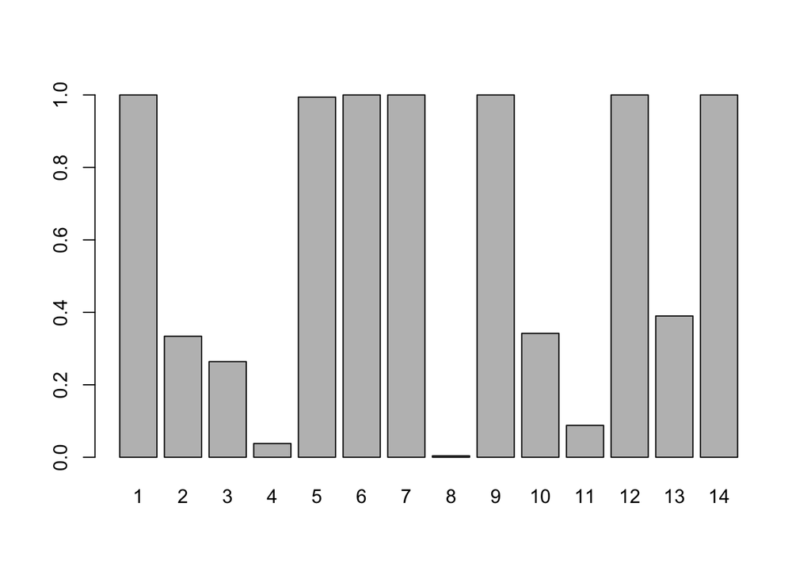

```r
data("BostonHousing")
y <- BostonHousing$medv
X <- cbind(1,BostonHousing[, -which(colnames(BostonHousing) == "medv")])
X[, "chas"] <- as.numeric(X[, "chas"])
X <- as.matrix(X)
lpy.X <- function(y,X, g=0.001) {
   n <- nrow(X)
   p <- ncol(X)
   if(is.null(p)){X=as.matrix(X);n=dim(X)[1] ; p=dim(X)[2]}
   H <- 0
   if(p>1){
      H <- 1/(g+1) * X%*%solve(t(X)%*%X)%*%t(X)
   }
   RSS<- t(y)%*%(diag(n)  - H) %*%y
  return((-n+p)/2*log(2*pi)-p/2*log(g+1)-
            1/2*log(det(t(X)%*%X))-lgamma(n/2-1)-n/2*log(RSS/2))
}
p <- ncol(X)
z <- rep(1,p)
lpy.current <- lpy.proposed <- lpy.X(y,X[, z==1])
S <- 500
Z <- matrix(0, S, ncol(X))
for(s in 1:S){
   for(j in sample(2:p)){
      z.propose <- z
      # if model includes covariate j, propose removing
      # else if model doesn't include, propose including
      z.propose[j] <- 1 - z.propose[j]
      # log-likelihood of proposed
      lpy.proposed <- lpy.X(y, X[, z.propose==1])
      # log-likelihood will always be less if proposing to include
      # so correct order by multiplying by -1
      r <- (lpy.proposed - lpy.current)*(-1)^(z.propose[j]==0)
      # sample from bernoulli with probability p=exp(-r)
      # to adjust for log scale
      z[j] <- rbernoulli(1,1/(1+exp(-r)))
      if(z[j] == z.propose[j]){
         lpy.current <- lpy.proposed
      }
   }
   Z[s,] <- z
   }
inclusion_probs <- colMeans(Z[1:(1*S),])
barplot(inclusion_probs, names.arg = 1:p)
```

```r
median_model <- which(inclusion_probs >= 0.5)
X_med <- X[, median_model]
X_medtX_med_inv <- solve(t(X_med)%*%X_med)
XtXinv <- solve(t(X)%*%X)
n = length(y)
S = 1000
beta_chain <- matrix(0, nrow = ncol(X_med), ncol = S)
beta_chain_avg <- matrix(0, nrow = ncol(X), ncol = S)
g = 0.001
for(i in 1:S){
   #Sampling sigma2
   sigma2 <- rinvgamma(n = 1, shape = n/2 - 1,
                     rate = 1/2*t(y)%*%
                      (diag(n) - 1/(1 + g)*X_med%*%X_medtX_med_inv%*%
                          t(X_med))%*%y)
   M = sigma2/(1 + g)*X_medtX_med_inv
   m = 1/sigma2*t(X_med)%*%y
   beta_chain[, i] <- t(as.matrix(rmvnorm(n = 1, mean = M%*%m, sigma = M)))

   sigma2 <- rinvgamma(n = 1, shape = n/2 - 1,
                     rate = 1/2*t(y)%*%
                      (diag(n) - 1/(1 + g)*X%*%XtXinv%*%
                          t(X))%*%y)
   M = sigma2/(1 + g)*XtXinv
   m = 1/sigma2*t(X)%*%y
   beta_chain_avg[, i] <- t(as.matrix(rmvnorm(n = 1, mean = M%*%m, sigma = M)))
}
```

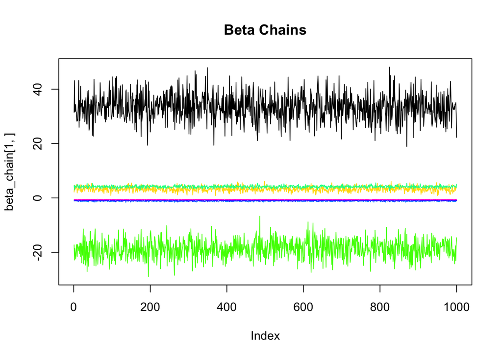

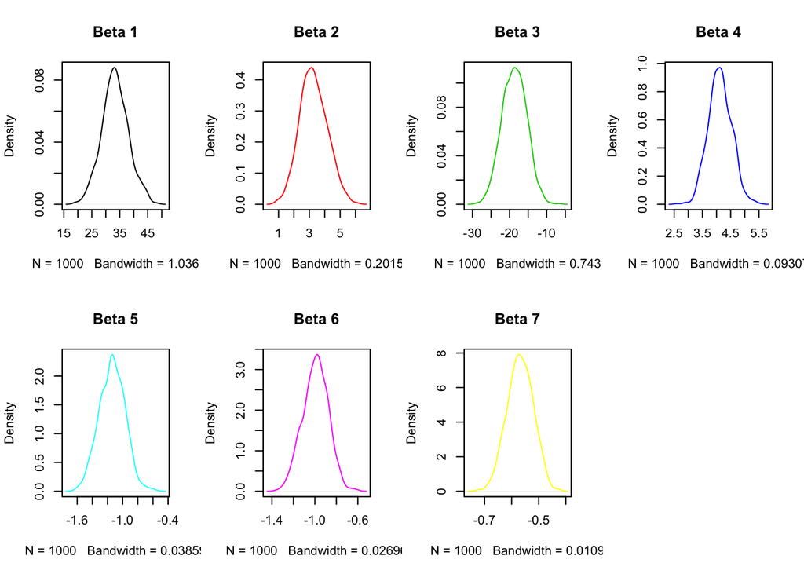

It’s really interesting how the median model in stochastic variable selection leaves out essentially every small coefficient. I’ve made a table comparing the median model along with the set of averaged coefficients and LASSO.

|  | Median | Average | LASSO |
| --- | --- | --- | --- |
| (Intercept) | 33.346 | 33.739 | 32.525 |
| crim | NA | -0.109 | -0.103 |
| zn | NA | 0.046 | 0.043 |
| indus | NA | 0.019 | 0.000 |
| chas | 3.277 | 2.667 | 2.700 |
| nox | -18.710 | -17.716 | -16.756 |
| rm | 4.123 | 3.808 | 3.840 |
| age | NA | 0.000 | 0.000 |
| dis | -1.139 | -1.479 | -1.437 |
| rad | NA | 0.305 | 0.272 |
| tax | NA | -0.012 | -0.011 |
| ptratio | -0.994 | -0.952 | -0.937 |
| b | NA | 0.009 | 0.009 |
| lstat | -0.569 | -0.524 | -0.523 |

For this part, I’ll sample from the posterior predictive distribution for each testing data point

This gives me a way to quantify uncertainty about each prediction in that I’m accounting for both model uncertainty and parameter uncertainty. For an ultimate point estimate, I can use BMA. just need to average over the sampled $\beta$ values and take $\hat y=X_{\text{test}}\beta_{\text{bma}}$.

```r
train_ind = sample(seq_len(nrow(X)),size = floor(0.75*nrow(X)) )
trainX = X[train_ind,]; testX = X[-train_ind,]
trainy = y[train_ind]; testy = y[-train_ind]
S <- 200
beta_chain <- matrix(0, nrow = p, ncol = S)
beta <- rep(0, p)
predictions <- matrix(0, nrow = length(testy), ncol = S)
for(j in 1:S){
   # sample gamma
   gamma <- Z[j, ]
   X <- trainX[, which(gamma == 1)]
   y <- trainy
   sigma2 <- rinvgamma(n = 1, shape = nrow(X)/2 - 1,
                     rate = 1/2*t(y)%*%
                      (diag(nrow(X)) - 1/(1 + g)*X%*%solve(t(X)%*%X)%*%
                          t(X))%*%y)
   M = sigma2/(1 + g)*solve(t(X)%*%X)
   m = 1/sigma2*t(X)%*%y
   beta[which(gamma==1)] <- t(as.matrix(rmvnorm(n = 1, mean = M%*%m, sigma = M)))
   beta_chain[, j] <- beta
   predictions[, j] <- testX %*% beta
}
```

| BMA.RMSE | Lasso.RMSE |
| --- | --- |
| 6.3 | 5.55 |

It’s expected that the BMA estimate has worse predictive capicity, since the highest probability models have 5 less covariates than the cross-validated lasso estimate.